# Loto code

```python
import pandas as pd
import numpy as np
import matplotlib.pyplot as plt
import re
import datetime
%matplotlib inline

from scipy.stats import chisquare
from scipy.stats import anderson
```

#### Monte Carlo computation of the chi2 test on a dice

```python
def role_dice(n):
    out = np.random.randint(1,7,n)
    exp = float(n)/6 # we expect having each nmumber n/6 times
    obs = [(out==i).sum() for i in np.arange(1,7)] # true observations
    T = [(obs[i]-exp)**2/exp for i in np.arange(6)]
    T = np.sum(T)
    return T

n_exp = 10000
n_simul = 1000
T = []
for n in np.arange(n_exp):
    T.extend([role_dice(n_simul)])

print(np.percentile(T,95))
```

```
11.06
```

## Let's play with the lottery data

```python
data = pd.read_csv('/home/romain/Documents/Github/loto/data/nouveau_loto.csv',sep=';',index_col=False)
del data['Unnamed: 25'] # the file end each line with a semi-colon which causes an empty column
print(data.shape)
```

```
(1152, 25)
```

```python
data.head()
```

|  | annee_numero_de_tirage | jour_de_tirage | date_de_tirage | date_de_forclusion | boule_1 | boule_2 | boule_3 | boule_4 | boule_5 | numero_chance | ... | nombre_de_gagnant_au_rang3 | rapport_du_rang3 | nombre_de_gagnant_au_rang4 | rapport_du_rang4 | nombre_de_gagnant_au_rang5 | rapport_du_rang5 | nombre_de_gagnant_au_rang6 | rapport_du_rang6 | numero_jokerplus | devise |
| --- | --- | --- | --- | --- | --- | --- | --- | --- | --- | --- | --- | --- | --- | --- | --- | --- | --- | --- | --- | --- | --- |
| 0 | 2016019 | SAMEDI | 13/02/2016 | 14/04/2016 | 38 | 30 | 27 | 41 | 10 | 4 | ... | 971 | 1130,9 | 43256 | 11 | 634259 | 5,3 | 910674 | 2 | 1 678 529 | eur |
| 1 | 2016018 | MERCREDI | 10/02/2016 | 11/04/2016 | 44 | 46 | 1 | 27 | 48 | 10 | ... | 285 | 1813,1 | 16519 | 13,5 | 258725 | 6,1 | 338890 | 2 | 5 758 628 | eur |
| 2 | 2016017 | LUNDI | 08/02/2016 | 09/04/2016 | 30 | 1 | 28 | 39 | 11 | 6 | ... | 345 | 1662,4 | 17037 | 9,9 | 244222 | 4,9 | 348441 | 2 | 3 908 634 | eur |
| 3 | 2016016 | SAMEDI | 06/02/2016 | 07/04/2016 | 44 | 25 | 2 | 41 | 28 | 9 | ... | 520 | 1341 | 24482 | 12,3 | 379330 | 5,6 | 551760 | 2 | 3 328 398 | eur |
| 4 | 2016015 | MERCREDI | 03/02/2016 | 04/04/2016 | 5 | 44 | 24 | 28 | 25 | 3 | ... | 565 | 1100,9 | 28453 | 9,4 | 400389 | 4,8 | 538287 | 2 | 9 178 211 | eur |

5 rows × 25 columns

### Application of the chi2 test on the lottery data - Does some numbers get out more often ?

#### Classic numbers

```
<Container object of 49 artists>
```

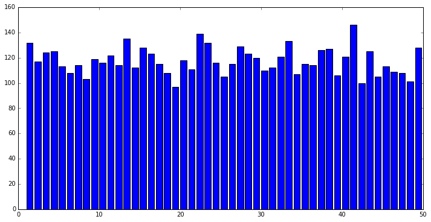

```python
boule = pd.concat([data['boule_1'],data['boule_2'],data['boule_3'],data['boule_4'],data['boule_5']])
freq = boule.value_counts()
plt.figure(figsize=(12,6))
plt.bar(list(freq.index),freq)
```

**Is this odd ?**

> To check it, we will use the chi-2 test with 48 degree of freedom that the observation come from a multionomial law

```python
chisquare(freq)
```

```
Power_divergenceResult(statistic=45.870486111111113, pvalue=0.56051711176708841)
```

> The p-value is really high, so we do not reject H0 and thus there is nothing abnormal there

#### The 'numero chance'

```
 <a list of 10 Text xticklabel objects>)
```

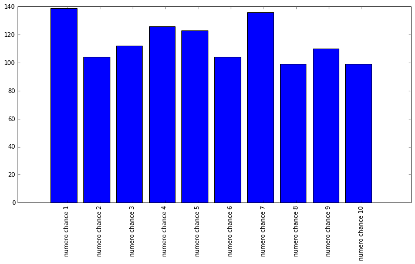

```python
freq_chance = data['numero_chance'].value_counts()
plt.figure(figsize=(12,6))
plt.bar(list(freq_chance.index),freq_chance)
plt.xticks(np.arange(1,11)+0.5,
                   ["numero chance "+str(i+1) for i in np.arange(10)],rotation='vertical')
```

```python
chisquare(freq_chance)
```

```
Power_divergenceResult(statistic=17.270833333333332, pvalue=0.044639864855720156)
```

> This one is a little more litigous ... Most of the time we want a p-value greater than 0.05 ... It may be a good idea to choose 1 as a 'numero chance'

#### What about pairs ?

```python
def search(x,i):
    a = re.search(r"(^|-)"+str(i)+"(-|\+)",x)
    if a:
        out = True
    else:
        out = False
    return out

pairs = np.zeros((49,49))
for i in np.arange(1,50):
    ind_i = list(map(lambda x: search(x,i),data['combinaison_gagnante_en_ordre_croissant']))
    subdata_i = data.ix[ind_i]
    for j in np.arange(i+1,50):
        ind_ij = list(map(lambda x: search(x,j),subdata_i['combinaison_gagnante_en_ordre_croissant']))
        pairs[i-1,j-1] = np.sum(ind_ij)
        pairs[j-1,i-1] = np.sum(ind_ij)
```

```
 <a list of 49 Text yticklabel objects>)
```

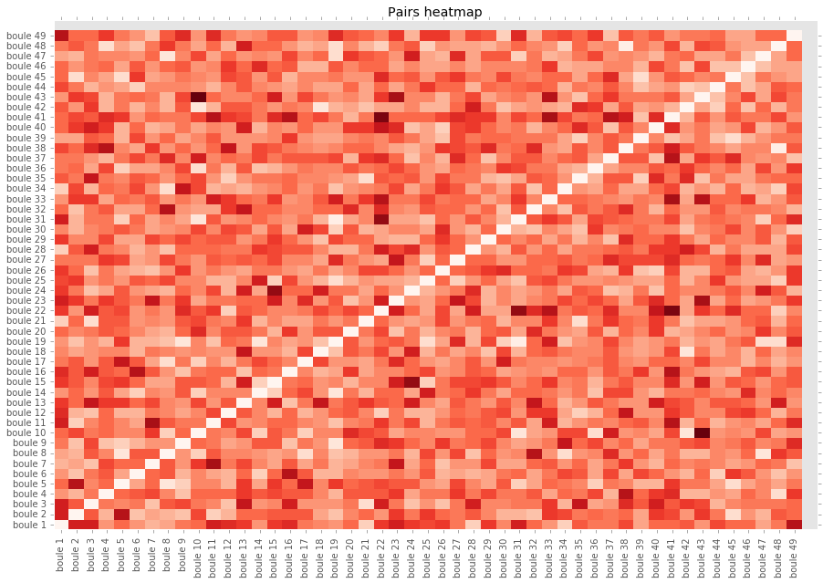

```python
pairs = pd.DataFrame(pairs)
plt.style.use('ggplot')
plt.figure(figsize=(15,10))
plt.title('Pairs heatmap')
plt.pcolor(pairs,cmap=plt.cm.Reds)
width = .5
height = .5
plt.xticks(np.arange(pairs.shape[0])+width,
           ["boule "+str(i+1) for i in np.arange(pairs.shape[1])],rotation='vertical')
plt.yticks(np.arange(pairs.shape[0])+width,
           ["boule "+str(i+1) for i in np.arange(pairs.shape[1])])
```

```python
ind = np.triu_indices(49,1)
chisquare(np.array(pairs)[ind])
```

```
Power_divergenceResult(statistic=1224.4916666666668, pvalue=0.15371052190725559)
```

> Again, the p-value is really high, so we do not reject H0 and thus there is nothing abnormal there. Too bad for us :)

### On the winning probability

#### Over the years

```python
data['date'] = list(map(lambda x: datetime.datetime.strptime(x,'%d/%m/%Y').date(),data['date_de_tirage']))
```

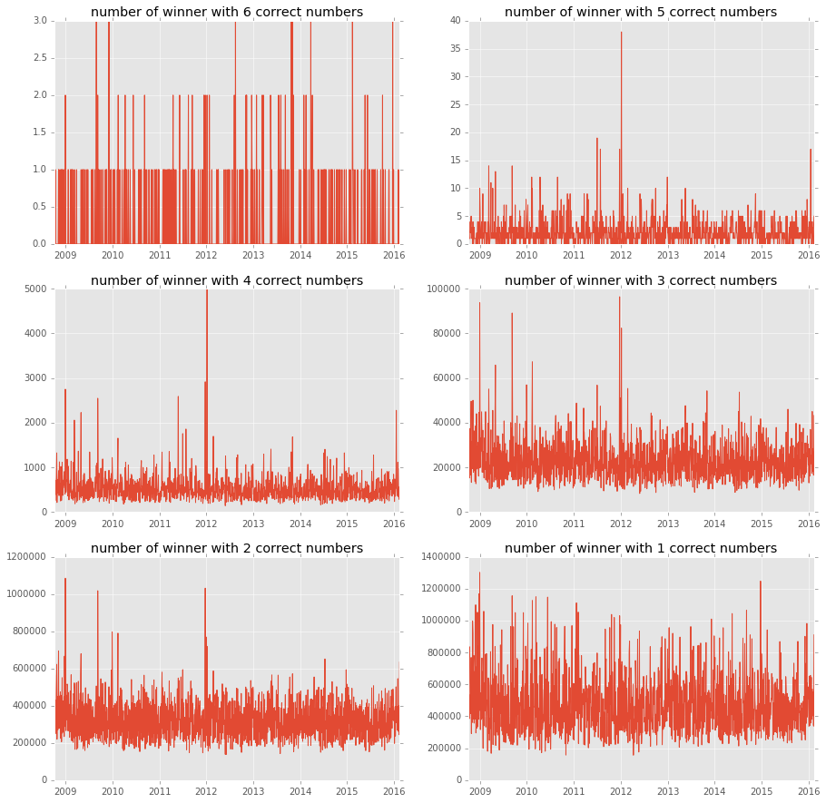

```python
f, axarr = plt.subplots(3, 2,figsize=(15,15))
for i in np.arange(6):
    r = int(i/2)
    c = i%2
    axarr[r,c].plot(data['date'],data['nombre_de_gagnant_au_rang'+str(i+1)])
    axarr[r,c].set_title('number of winner with '+str(6-i)+' correct numbers')
plt.show()
```

> There does not seem to be a winning trend over the years. Now is not better than before !

#### The day of the week ?

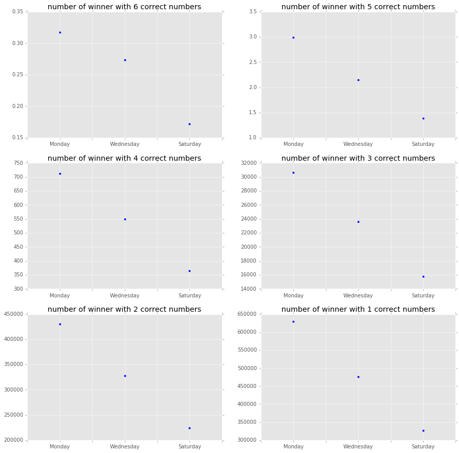

```python
f, axarr = plt.subplots(3, 2,figsize=(15,15))
days = list(set(data['jour_de_tirage']))
for i in np.arange(6):
    r = int(i/2)
    c = i%2
    tab = [np.mean(data['nombre_de_gagnant_au_rang'+str(i+1)][data['jour_de_tirage']==days[k]])
           for k in np.arange(len(days))]
    axarr[r,c].scatter(np.arange(len(days)),tab)
    axarr[r,c].set_title('number of winner with '+str(6-i)+' correct numbers')
    axarr[r,c].set_xticklabels(['','Monday','','Wednesday','','Saturday',''])
plt.show()
```

```python
days = list(set(data['jour_de_tirage']))
uplift = []
for i in np.arange(6):
    monday = np.mean(data['nombre_de_gagnant_au_rang'+str(i+1)][data['jour_de_tirage']==days[0]])
    restOfWeek = np.mean(data['nombre_de_gagnant_au_rang'+str(i+1)][data['jour_de_tirage']!=days[0]])
    uplift.extend([(restOfWeek-monday)/restOfWeek*100])
print(np.mean(uplift))
```

```
-55.9805515698
```

#### The month

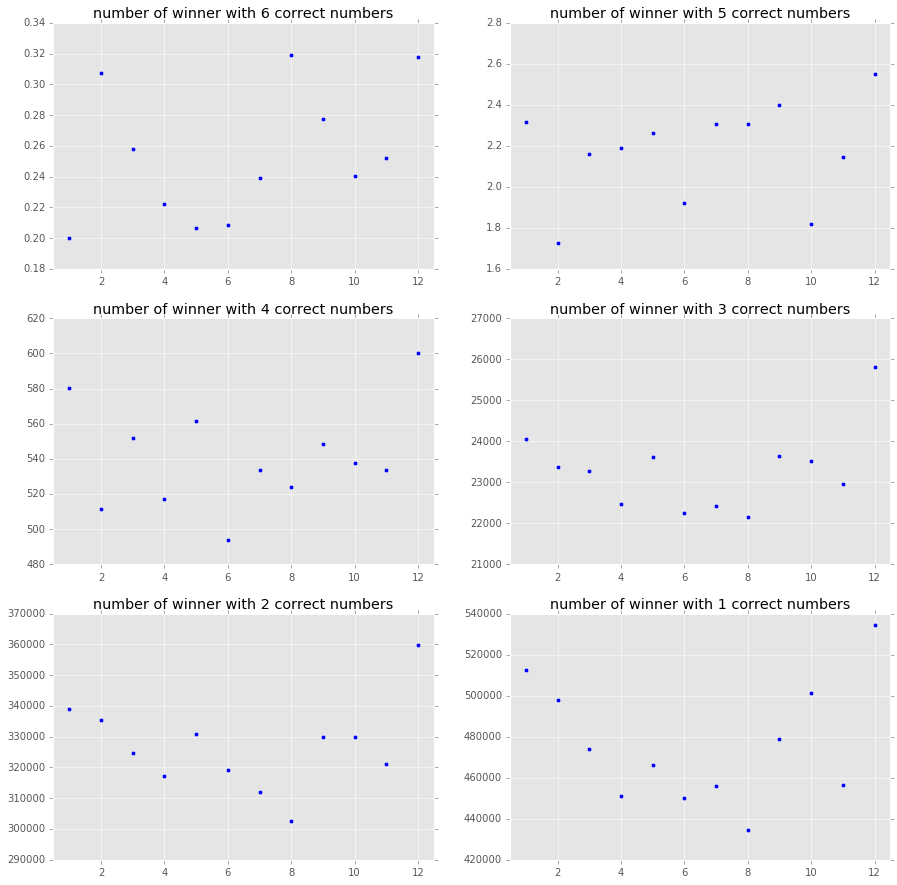

```python
data['month'] = list(map(lambda dt: dt.month,data['date']))
f, axarr = plt.subplots(3, 2,figsize=(15,15))
for i in np.arange(6):
    r = int(i/2)
    c = i%2
    tab = [np.mean(data['nombre_de_gagnant_au_rang'+str(i+1)][data['month']==k])
           for k in np.arange(1,13)]
    axarr[r,c].scatter(np.arange(1,13),tab)
    axarr[r,c].set_title('number of winner with '+str(6-i)+' correct numbers')
    axarr[r,c].set_xlim([0.5,12.5])
plt.show()
```

> It seems that there is less opponents during summer. Just sayin' ...

```python
uplift = []
for i in np.arange(6):
    june = np.mean(data['nombre_de_gagnant_au_rang'+str(i+1)][(data['month']==6)])
    restOfYear = np.mean(data['nombre_de_gagnant_au_rang'+str(i+1)][(data['month']!=6)])
    uplift.extend([(restOfYear-june)/restOfYear*100])
print(np.mean(uplift))
```

```
9.21154412795
```